# Pronóstico para el tipo de cambio diario pesos-dólar.

En esta notebook buscamos realizar un pronóstico para el tipo de cambio diario pesos-dólar: Usando información del periodo “2002-01-01”-“2021-11-30” con las siguiente variables:

- (Banxico) Tipo de cambio, pesos por dólar E.U.A. (ln)
- (Banxico/INEGI) Producto interno bruto, cambio porcentual.(ln)
- (BEA) Percent Change From Preceding Period in Real Gross Domestic Product.(ln)
- (Banxico) Tasas de interés en el mercado de dinero. (0.25 ln(1 + Rt/100))
- (Nasdaq) interest rate on U.S. government.(0.25 ln(1 + Rt/100))
- (Banxico) Índice Nacional de Precios al consumidor.(ln)
- (BLS) Consumer Price Index.(ln)

**Librerías**

```r
library(readr)
library(dplyr)

#series de tiempo
library(xts)
library(tseries)
library(tsDyn)
library(vars)
library(forecast)
library(tidyverse)
library(gridExtra)
```

**Funciones**

```r
#Prueba de estacionaridad múltiples variables
estacion_test <- function(dataset){
  p_values<-NULL
  for(i in 1:ncol(dataset)){
    aux <- pp.test(dataset[,i])
    p_values<-c(p_values,aux$p.value)
  }
  names(p_values)<-colnames(dataset)
  return(p_values)
}

#Convertir data a trimestral sumarizando a media
qdata<- function(dataset){
  dataset$qdate<- as.yearqtr(dataset$date) #obtener fecha trimestral
  dataset$qdate<-as.Date(as.yearqtr(dataset$qdate, "%Y-%m-%d")) #Convertir trimestral de string a date
  data_q<-dataset %>% group_by(qdate) %>% summarise_all(mean)  %>%select(c("qdate","value")) #seleccionar solo fecha trimestral y valor
  return(data_q)
}

#Convertir data a mensual sumarizando a media
mdata<- function(dataset){
  dataset$mdate<- as.yearmon(dataset$date) #obtener fecha mensual
  dataset$mdate<-as.Date(as.yearmon(dataset$mdate, "%Y-%m-%d")) #Convertir mensual de string a date
  data_m<-dataset %>% group_by(mdate) %>% summarise_all(mean) #seleccionar solo fecha mensual y valor
  data_m<-data_m[,c("mdate","value")]
  return(data_m)
}
#Convertir data a diaria

ddata<-function(dataset){
  datset_d <- xts(dataset$value,order.by = dataset$date)
  datset_d <- na.locf(merge(datset_d , foo=zoo(NA, order.by=seq(as.Date("2002-01-01","%Y-%m-%d"), as.Date("2021-11-30","%Y-%m-%d"),"day",drop=F)))[, 1])
  datset_d <-as.data.frame(list(rownames(as.data.frame(datset_d )),as.data.frame(datset_d)$datset_d))
  names(datset_d)<-c("date","value")
  return(datset_d)
  }
```

### Obtener datos creados anteriormente en notebook ‘Obtención de datos’

```r
TC_df_<- read_csv("csv_files/TC_df.csv") #diaria
IPC_df<- read_csv("csv_files/IPC_df.csv") #mensual
CPI_df<- read_csv("csv_files/CPI_df.csv")#mensual
GDP_df<- read_csv("csv_files/GDP_df.csv") #trimestral
PIB_df<- read_csv("csv_files/PIBb_df.csv") #trimestral
TI_df<- read_csv("csv_files/TI_df.csv")#diaria ! Datos desde 2008
IR_df<- read_csv("csv_files/IR_df.csv")#daily with lacks

#Acortar periodos de tiempo,información antes del 30 de Noviembre
TC_df<-subset(TC_df_, date <=as.Date("2021-11-30"))#diaria
IPC_df<-subset(IPC_df, date <=as.Date("2021-11-30"))#mensual
CPI_df<-subset(CPI_df, date <=as.Date("2021-11-30"))#mensual
GDP_df<-subset(GDP_df, date <=as.Date("2021-11-30"))#trimestral
PIB_df<-subset(PIB_df, date <=as.Date("2021-11-30"))#trimestral
IR_df<-subset(IR_df, (date <=as.Date("2021-11-30") & date >=as.Date("2002-01-01")))#daily with lacks
```

### Visualizaciones series

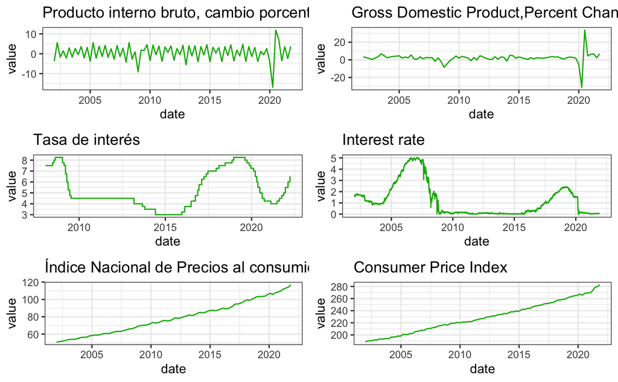

```r
p7<-ggplot(NULL, aes(x=date, y=value)) +geom_line(color="#00b300", data=TC_df)+ggtitle("Tipo de cambio, pesos por dólar E.U.A.")+theme_bw()
p1<-ggplot(NULL, aes(x=date, y=value )) +geom_line(color="#00b300", data=PIB_df)+ggtitle("Producto interno bruto, cambio porcentual")+theme_bw()

p2<-ggplot(NULL, aes(x=date, y=value)) +geom_line(color="#00b300", data=GDP_df)+ggtitle("Gross Domestic Product,Percent Change")+theme_bw()
p3<-ggplot(NULL, aes(x=date, y=value)) +geom_line(color="#00b300", data=TI_df)+ggtitle("Tasa de interés")+theme_bw()
#p3<-ggplot(NULL, aes(x=date, y=value)) +geom_line(color="#00b300", data=PIB_df)+ggtitle("Producto interno bruto Producto interno bruto, a precios de mercado")
#PIB no se considera dado que solo aparecen datos hasta 2021
p4<-ggplot(NULL, aes(x=date, y=value)) +geom_line(color="#00b300", data=IR_df) +ggtitle("Interest rate")+theme_bw()

p5<-ggplot(NULL, aes(x=date, y=value)) +geom_line(color="#00b300", data=IPC_df)+ggtitle("Índice Nacional de Precios al consumidor ")+theme_bw()
p6<-ggplot(NULL, aes(x=date, y=value)) +geom_line(color="#00b300", data=CPI_df)+ggtitle("Consumer Price Index")+theme_bw()
grid.arrange(p1,p2,p3,p4,p5,p6)
```

### Serie Tasa de Cambio

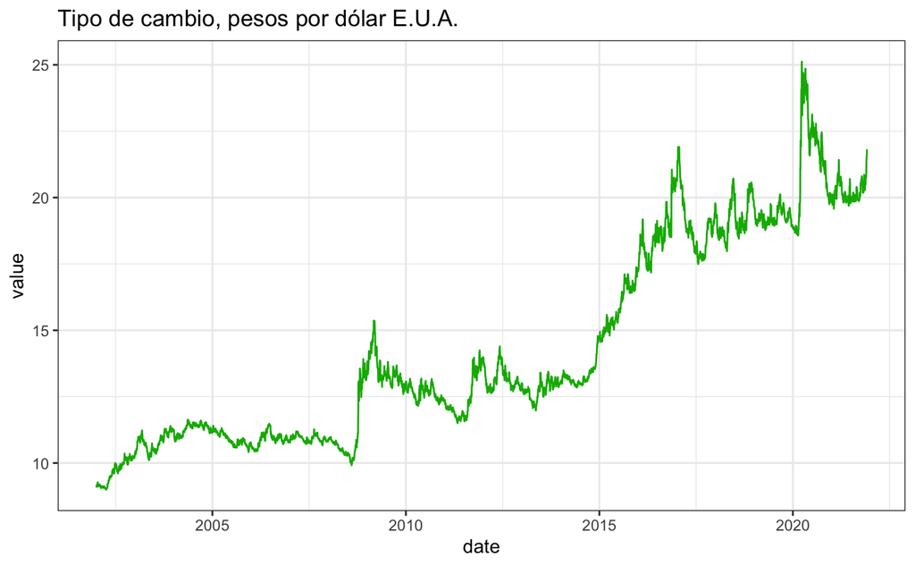

```r
p7
```

```r
#Definir series de tiempo
TC.ts<-ts(TC_df$value,  start = c(2002, as.numeric(format(TC_df$date[1], "%j"))),frequency = 365)
IPC.ts<-ts(IPC_df$value, start = c(2002, 1), frequency = 12)
CPI.ts<-ts(CPI_df$value, start = c(2002, 1), frequency = 12)
GDP.ts<-ts(GDP_df$value, start = c(2002, 1), frequency = 4)
PIB.ts<-ts(PIB_df$value, start = c(2002, 1), frequency = 4)
IR.ts<-ts(IR_df$value,  start = c(2002, as.numeric(format(IR_df$date[1], "%j"))),frequency = 365)
```

```r
#Verificar estacionariedad de series
cat("valor-p para TC:",pp.test(TC.ts)$p.value,"\n")
```

```
valor-p para TC: 0.2435405
```

```r
cat("\nvalor-p para IPC:",pp.test(IPC.ts)$p.value)
```

```
p-value greater than printed p-value
```

```
valor-p para IPC: 0.99
```

```r
cat("\nvalor-p para CPI:",pp.test(CPI.ts)$p.value)
```

```
valor-p para CPI: 0.1482588
```

```r
cat("\nvalor-p para GDP:",pp.test(GDP.ts)$p.value)
```

```
p-value smaller than printed p-value
```

```
valor-p para GDP: 0.01
```

```r
cat("\nvalor-p para PIB:",pp.test(PIB.ts)$p.value)
```

```
p-value smaller than printed p-value
```

```
valor-p para PIB: 0.01
```

```r
cat("\nvalor-p para TR:",pp.test(IR.ts)$p.value)
```

```
valor-p para TR: 0.9551491
```

Dado que para nuestra serie principal TC no tenemos pruebas estadísticamente significativas de que sea estacionaria y recordando que, una combinacion de variables no estacionarias puede ser estacionaria, intentaremos construir un modelo VECM descartando las variables PIB, GDP

```r
#Convertir data a diaria para tener todas las series con la misma perioricidad.
#Nota: En este paso también se podría intentar un método de interpolación, por ahora solo se repiten los valores en los días

TC_df_d<- ddata(TC_df)
IPC_df_d<-ddata(IPC_df)
CPI_df_d<-ddata(CPI_df)
IR_df_d<-ddata(IR_df)
IR_df_d[is.na(IR_df_d)] <- 0 #EnIR no tenemos el primer valor
```

```r
#Definir series
TC_df_d.ts<-ts(TC_df_d$value, start = c(2002, 1), frequency = 365)
IPC_df_d.ts<-ts(IPC_df_d$value, start = c(2002, 1), frequency = 365)
CPI_df_d.ts<-ts(CPI_df_d$value, start = c(2002, 1), frequency = 365)
IR_df_d.ts<-ts(IR_df_d$value, start = c(2002, 1), frequency = 365)


#Transformar data a ln para verificar posible estacionaridad
log_TC_df_d.ts <- log(TC_df_d.ts)
log_IPC_df_d.ts <- log(IPC_df_d.ts)
log_CPI_df_d.ts <- log(CPI_df_d.ts)
log_IR_df_d.ts <-.25*(log(1+(IR_df_d.ts/100))) #Valor usado comúnmente en econometría


se_log_data <- cbind(log_TC_df_d.ts ,log_IPC_df_d.ts,log_CPI_df_d.ts,log_IR_df_d.ts)

# Pruebas de estacionaridad
estacion_test(se_log_data)
```

```
 log_TC_df_d.ts log_IPC_df_d.ts log_CPI_df_d.ts  log_IR_df_d.ts
     0.21191736      0.05651108      0.66627322      0.84860979
```

Seguimos teniendo series sin prubas estadísticamente significativas de que sean estacionarias, procedemos a construir VECM

```r
#Seleccionar el número óptimo de lags
#Akaike, Hannan-Quinn, Schwarz, and Final Prediction Error
VARselect(se_log_data, type = "const")
```

```
$selection
AIC(n)  HQ(n)  SC(n) FPE(n)
     9      3      1      9

$criteria
                   1             2             3             4             5             6
AIC(n) -5.864071e+01 -5.864817e+01 -5.866088e+01 -5.866032e+01 -5.866396e+01 -5.867138e+01
HQ(n)  -5.863418e+01 -5.863642e+01 -5.864391e+01 -5.863813e+01 -5.863655e+01 -5.863875e+01
SC(n)  -5.862173e+01 -5.861402e+01 -5.861155e+01 -5.859581e+01 -5.858428e+01 -5.857652e+01
FPE(n)  3.409296e-26  3.383953e-26  3.341224e-26  3.343096e-26  3.330937e-26  3.306306e-26
                   7             8             9            10
AIC(n) -5.867056e+01 -5.867125e+01 -5.867562e+01 -5.867464e+01
HQ(n)  -5.863271e+01 -5.862818e+01 -5.862733e+01 -5.862113e+01
SC(n)  -5.856052e+01 -5.854603e+01 -5.853523e+01 -5.851907e+01
FPE(n)  3.309034e-26  3.306746e-26  3.292324e-26  3.295559e-26
```

```r
#lapply(se_log_data, VARselect) #selección de lags por separadoo
```

```r
ca_jo_trace <- ca.jo(se_log_data, type = "trace", ecdet = "const", K = 8)
summary(ca_jo_trace)
```

```
######################
# Johansen-Procedure #
######################

Test type: trace statistic , without linear trend and constant in cointegration

Eigenvalues (lambda):
[1]  2.449892e-02  4.510799e-03  1.757569e-03  3.462652e-04 -4.470237e-18

Values of teststatistic and critical values of test:

           test 10pct  5pct  1pct
r <= 3 |   2.52  7.52  9.24 12.97
r <= 2 |  15.30 17.85 19.96 24.60
r <= 1 |  48.15 32.00 34.91 41.07
r = 0  | 228.37 49.65 53.12 60.16

Eigenvectors, normalised to first column:
(These are the cointegration relations)

                   log_TC_df_d.ts.l8 log_IPC_df_d.ts.l8 log_CPI_df_d.ts.l8 log_IR_df_d.ts.l8
log_TC_df_d.ts.l8            1.00000           1.000000           1.000000          1.000000
log_IPC_df_d.ts.l8         -27.16218           7.128682          -6.722903         -4.884291
log_CPI_df_d.ts.l8          61.14706         -17.139789          11.261563          9.102355
log_IR_df_d.ts.l8           81.92676          10.357712         -32.773507         53.097091
constant                  -207.53324          59.450003         -34.488974        -31.014536
                     constant
log_TC_df_d.ts.l8    1.000000
log_IPC_df_d.ts.l8  -3.447840
log_CPI_df_d.ts.l8   9.439601
log_IR_df_d.ts.l8  -48.904659
constant           -38.791661

Weights W:
(This is the loading matrix)

                  log_TC_df_d.ts.l8 log_IPC_df_d.ts.l8 log_CPI_df_d.ts.l8 log_IR_df_d.ts.l8
log_TC_df_d.ts.d       1.911802e-05      -1.616823e-03      -3.136451e-05     -3.726847e-04
log_IPC_df_d.ts.d      1.415928e-05       1.510561e-05       1.130515e-04      1.127558e-05
log_CPI_df_d.ts.d      6.884114e-06       4.593845e-05      -6.802272e-05      1.995417e-06
log_IR_df_d.ts.d      -5.700577e-08       3.502358e-05       4.614194e-06     -3.791527e-06
                       constant
log_TC_df_d.ts.d   1.056606e-15
log_IPC_df_d.ts.d  9.234653e-17
log_CPI_df_d.ts.d -1.014433e-16
log_IR_df_d.ts.d  -3.441761e-17
```

```r
ca_jo_eig<-ca.jo(se_log_data, type = "eigen", ecdet = "const", K = 8)
summary(ca_jo_eig)
```

```
######################
# Johansen-Procedure #
######################

Test type: maximal eigenvalue statistic (lambda max) , without linear trend and constant in cointegration

Eigenvalues (lambda):
[1]  2.449892e-02  4.510799e-03  1.757569e-03  3.462652e-04 -4.470237e-18

Values of teststatistic and critical values of test:

           test 10pct  5pct  1pct
r <= 3 |   2.52  7.52  9.24 12.97
r <= 2 |  12.78 13.75 15.67 20.20
r <= 1 |  32.85 19.77 22.00 26.81
r = 0  | 180.23 25.56 28.14 33.24

Eigenvectors, normalised to first column:
(These are the cointegration relations)

                   log_TC_df_d.ts.l8 log_IPC_df_d.ts.l8 log_CPI_df_d.ts.l8 log_IR_df_d.ts.l8
log_TC_df_d.ts.l8            1.00000           1.000000           1.000000          1.000000
log_IPC_df_d.ts.l8         -27.16218           7.128682          -6.722903         -4.884291
log_CPI_df_d.ts.l8          61.14706         -17.139789          11.261563          9.102355
log_IR_df_d.ts.l8           81.92676          10.357712         -32.773507         53.097091
constant                  -207.53324          59.450003         -34.488974        -31.014536
                     constant
log_TC_df_d.ts.l8    1.000000
log_IPC_df_d.ts.l8  -3.447840
log_CPI_df_d.ts.l8   9.439601
log_IR_df_d.ts.l8  -48.904659
constant           -38.791661

Weights W:
(This is the loading matrix)

                  log_TC_df_d.ts.l8 log_IPC_df_d.ts.l8 log_CPI_df_d.ts.l8 log_IR_df_d.ts.l8
log_TC_df_d.ts.d       1.911802e-05      -1.616823e-03      -3.136451e-05     -3.726847e-04
log_IPC_df_d.ts.d      1.415928e-05       1.510561e-05       1.130515e-04      1.127558e-05
log_CPI_df_d.ts.d      6.884114e-06       4.593845e-05      -6.802272e-05      1.995417e-06
log_IR_df_d.ts.d      -5.700577e-08       3.502358e-05       4.614194e-06     -3.791527e-06
                       constant
log_TC_df_d.ts.d   1.056606e-15
log_IPC_df_d.ts.d  9.234653e-17
log_CPI_df_d.ts.d -1.014433e-16
log_IR_df_d.ts.d  -3.441761e-17
```

Tenemos al menos 2 relaciones de cointegración

```r
#Contruir modelo VECM

Model1 <- VECM(se_log_data, 8, r = 2, estim =("ML")) #ML dado que tenemos más de una relación
summary(Model1)
```

```
#############
###Model VECM
#############
Full sample size: 7274  End sample size: 7265
Number of variables: 4  Number of estimated slope parameters 140
AIC -426275.8   BIC -425283.6   SSR 0.2493046
Cointegrating vector (estimated by ML):
   log_TC_df_d.ts log_IPC_df_d.ts log_CPI_df_d.ts log_IR_df_d.ts
r1   1.000000e+00               0       -2.568266     -13.094658
r2  -1.387779e-17               1       -2.048849       3.099934

                         ECT1                  ECT2                Intercept
Equation log_TC_df_d.ts  -0.0015(0.0007)*      -0.0110(0.0047)*    -0.0915(0.0340)**
Equation log_IPC_df_d.ts  7.3e-05(0.0001)      -0.0008(0.0007)     -0.0047(0.0052)
Equation log_CPI_df_d.ts -4.4e-05(5.3e-05)     0.0007(0.0004).     0.0040(0.0027)
Equation log_IR_df_d.ts   3.8e-05(9.9e-06)***  0.0002(7.0e-05)**   0.0019(0.0005)***
                         log_TC_df_d.ts -1   log_IPC_df_d.ts -1  log_CPI_df_d.ts -1
Equation log_TC_df_d.ts  0.0681(0.0117)***   0.1587(0.0872).     -0.1590(0.1685)
Equation log_IPC_df_d.ts -0.0001(0.0018)     -0.0144(0.0135)     -0.0233(0.0260)
Equation log_CPI_df_d.ts 0.0016(0.0009).     -0.0072(0.0070)     -0.0116(0.0135)
Equation log_IR_df_d.ts  -0.0001(0.0002)     -0.0012(0.0013)     0.0008(0.0025)
                         log_IR_df_d.ts -1  log_TC_df_d.ts -2   log_IPC_df_d.ts -2
Equation log_TC_df_d.ts  0.4531(0.7882)     -0.0237(0.0118)*    -0.1236(0.0873)
Equation log_IPC_df_d.ts 0.1492(0.1216)     -0.0003(0.0018)     -0.0141(0.0135)
Equation log_CPI_df_d.ts 0.0655(0.0630)     0.0003(0.0009)      -0.0069(0.0070)
Equation log_IR_df_d.ts  0.0801(0.0118)***  -0.0005(0.0002)**   -0.0010(0.0013)
                         log_CPI_df_d.ts -2  log_IR_df_d.ts -2   log_TC_df_d.ts -3
Equation log_TC_df_d.ts  -0.3380(0.1685)*    -2.7245(0.7901)***  -0.0208(0.0118).
Equation log_IPC_df_d.ts -0.0230(0.0260)     -0.1774(0.1219)      6.7e-05(0.0018)
Equation log_CPI_df_d.ts -0.0112(0.0135)     -0.0169(0.0631)      3.9e-05(0.0009)
Equation log_IR_df_d.ts  0.0015(0.0025)      -0.1080(0.0118)***  -2.2e-05(0.0002)
                         log_IPC_df_d.ts -3  log_CPI_df_d.ts -3  log_IR_df_d.ts -3
Equation log_TC_df_d.ts  0.1446(0.0873).     0.1052(0.1686)      1.5937(0.7945)*
Equation log_IPC_df_d.ts -0.0125(0.0135)     -0.0261(0.0260)     -0.1759(0.1226)
Equation log_CPI_df_d.ts -0.0062(0.0070)     -0.0111(0.0135)     -0.0082(0.0635)
Equation log_IR_df_d.ts  0.0019(0.0013)      0.0004(0.0025)      0.0226(0.0118).
                         log_TC_df_d.ts -4  log_IPC_df_d.ts -4  log_CPI_df_d.ts -4
Equation log_TC_df_d.ts  0.0282(0.0118)*    -0.1785(0.0873)*    0.1930(0.1685)
Equation log_IPC_df_d.ts 0.0028(0.0018)     -0.0138(0.0135)     -0.0244(0.0260)
Equation log_CPI_df_d.ts 0.0017(0.0009).    -0.0065(0.0070)     -0.0119(0.0135)
```

[output cut: 16 more lines]

```
                         log_TC_df_d.ts -7    log_IPC_df_d.ts -7  log_CPI_df_d.ts -7
Equation log_TC_df_d.ts  -0.0302(0.0118)*     0.0271(0.0873)      -0.3625(0.1685)*
Equation log_IPC_df_d.ts 0.0008(0.0018)       -0.0138(0.0135)     -0.0246(0.0260)
Equation log_CPI_df_d.ts 0.0007(0.0009)       -0.0066(0.0070)     -0.0102(0.0135)
Equation log_IR_df_d.ts   6.7e-05(0.0002)     -0.0014(0.0013)     0.0017(0.0025)
                         log_IR_df_d.ts -7   log_TC_df_d.ts -8    log_IPC_df_d.ts -8
Equation log_TC_df_d.ts  -0.0213(0.7896)     -0.0118(0.0117)      0.1154(0.0873)
Equation log_IPC_df_d.ts 0.0704(0.1218)      0.0050(0.0018)**     -0.0131(0.0135)
Equation log_CPI_df_d.ts 0.0391(0.0631)      -9.4e-05(0.0009)     -0.0068(0.0070)
Equation log_IR_df_d.ts  0.0475(0.0118)***   0.0004(0.0002)*      -0.0010(0.0013)
                         log_CPI_df_d.ts -8  log_IR_df_d.ts -8
Equation log_TC_df_d.ts  0.0332(0.1685)      -2.8260(0.6832)***
Equation log_IPC_df_d.ts -0.0228(0.0260)     0.1316(0.1054)
Equation log_CPI_df_d.ts -0.0107(0.0135)     0.1255(0.0546)*
Equation log_IR_df_d.ts  0.0005(0.0025)      0.0244(0.0102)*
```

```r
#Transformar VECM a VAR
vec2var_ca_jo_eig <- vec2var(ca_jo_eig, r=2)
```

```r
#Correlación de series
serial.test(vec2var_ca_jo_eig, lags.pt = 9, type = "PT.asymptotic")
```

```
    Portmanteau Test (asymptotic)

data:  Residuals of VAR object vec2var_ca_jo_eig
Chi-squared = 80.843, df = 20, p-value = 2.823e-09
```

```r
#Prueba de normalidad, residuales

#H0: La variable presenta una distribución normal
#H1: La variable presenta una distribución no normal
p_norm<- normality.test(vec2var_ca_jo_eig, multivariate.only = TRUE)
p_norm
```

```
$JB

    JB-Test (multivariate)

data:  Residuals of VAR object vec2var_ca_jo_eig
Chi-squared = 9398829, df = 8, p-value < 2.2e-16


$Skewness

    Skewness only (multivariate)

data:  Residuals of VAR object vec2var_ca_jo_eig
Chi-squared = 101084, df = 4, p-value < 2.2e-16


$Kurtosis

    Kurtosis only (multivariate)

data:  Residuals of VAR object vec2var_ca_jo_eig
Chi-squared = 9297746, df = 4, p-value < 2.2e-16
```

Rechazamos la hipótesis nula, los errores no siguen una distribución normal, podríamos buscar formas de mejorar este modelo.

```r
vec2var_ca_jo_eig
```

```
Coefficient matrix of lagged endogenous variables:

A1:
                log_TC_df_d.ts.l1 log_IPC_df_d.ts.l1 log_CPI_df_d.ts.l1 log_IR_df_d.ts.l1
log_TC_df_d.ts       1.066760e+00       0.1450048016      -0.1389570270        0.28159190
log_IPC_df_d.ts     -9.900105e-05       0.9858716450      -0.0224720771        0.15849618
log_CPI_df_d.ts      1.572619e-03      -0.0068789806       0.9884115371        0.07480526
log_IR_df_d.ts      -1.214762e-04      -0.0009055343       0.0003360815        1.08237938


A2:
                log_TC_df_d.ts.l2 log_IPC_df_d.ts.l2 log_CPI_df_d.ts.l2 log_IR_df_d.ts.l2
log_TC_df_d.ts      -9.269907e-02      -0.2841387864      -0.1779900728       -3.08942002
log_IPC_df_d.ts     -8.229607e-05       0.0009078932      -0.0004074551       -0.34071421
log_CPI_df_d.ts     -1.226648e-03       0.0002728174       0.0005279199       -0.08695609
log_IR_df_d.ts      -2.992366e-04       0.0002129299       0.0005567504       -0.19067894


A3:
                log_TC_df_d.ts.l3 log_IPC_df_d.ts.l3 log_CPI_df_d.ts.l3 log_IR_df_d.ts.l3
log_TC_df_d.ts       0.0031523301       0.2716356184       0.4415437975       4.674868819
log_IPC_df_d.ts      0.0003459449       0.0004615237      -0.0006389275      -0.017947770
log_CPI_df_d.ts     -0.0003050657       0.0006851942      -0.0002051272      -0.004873667
log_IR_df_d.ts       0.0004336313       0.0027799263      -0.0008546845       0.127280934


A4:
                log_TC_df_d.ts.l4 log_IPC_df_d.ts.l4 log_CPI_df_d.ts.l4 log_IR_df_d.ts.l4
log_TC_df_d.ts       0.0498282716      -0.3197330267       0.0909113029       -3.48462249
log_IPC_df_d.ts      0.0028400330      -0.0008167749       0.0005908827        0.07814696
log_CPI_df_d.ts      0.0015797924      -0.0004933244      -0.0008190204       -0.01402092
log_IR_df_d.ts      -0.0002618801      -0.0026533948      -0.0006220542       -0.07217191


A5:
                log_TC_df_d.ts.l5 log_IPC_df_d.ts.l5 log_CPI_df_d.ts.l5 log_IR_df_d.ts.l5
log_TC_df_d.ts      -0.0368376024       6.337179e-02      -0.1607186378        2.15300331
log_IPC_df_d.ts     -0.0022187294       3.150008e-04       0.0004189414        0.15880288
log_CPI_df_d.ts      0.0007096352      -3.917860e-06       0.0005642234        0.04625186
log_IR_df_d.ts      -0.0002359290      -2.070599e-04      -0.0003128223       -0.03749867
```

[output cut: 18 more lines]

```
A8:
                log_TC_df_d.ts.l8 log_IPC_df_d.ts.l8 log_CPI_df_d.ts.l8 log_IR_df_d.ts.l8
log_TC_df_d.ts       3.041862e-02       -0.024419868        0.373428701        0.10439971
log_IPC_df_d.ts     -1.114258e-03        0.013785359        0.022931847       -0.04875929
log_CPI_df_d.ts     -5.489360e-04        0.006296249        0.009965784       -0.03583772
log_IR_df_d.ts      -9.209921e-05        0.001444888       -0.001854770       -0.03634215


Coefficient matrix of deterministic regressor(s).

                    constant
log_TC_df_d.ts  -0.100087776
log_IPC_df_d.ts -0.002040494
log_CPI_df_d.ts  0.001302358
log_IR_df_d.ts   0.002093983
```

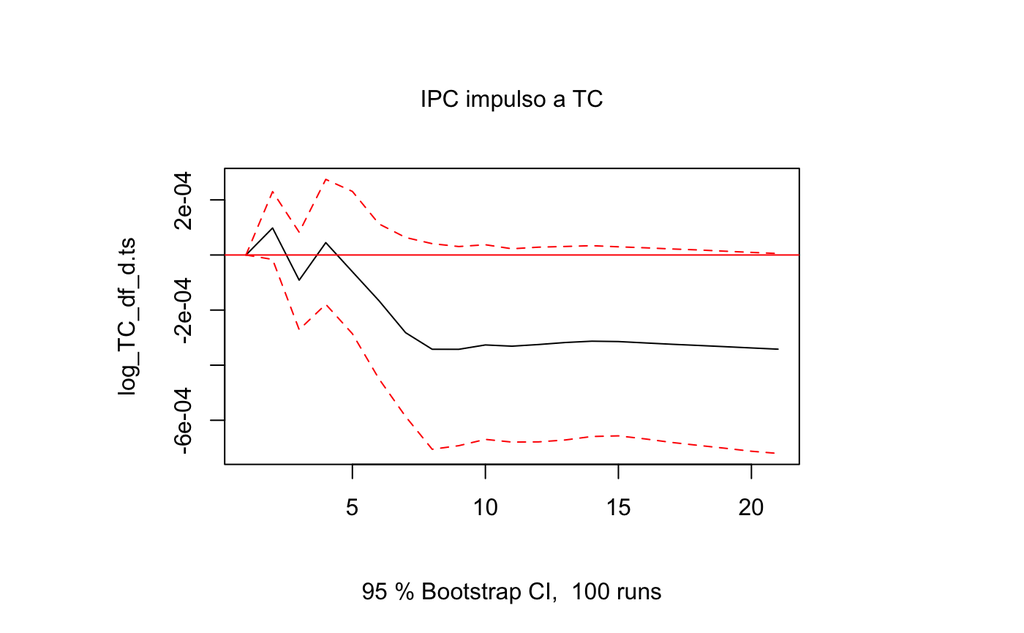

```r
#Funciones de respuesta al impulso

M1<- irf(vec2var_ca_jo_eig, impulse = "log_IPC_df_d.ts", response = "log_TC_df_d.ts", n.ahead = 20, boot = TRUE)
plot(M1, ylab = "log_TC_df_d.ts", main = "IPC impulso a TC")
```

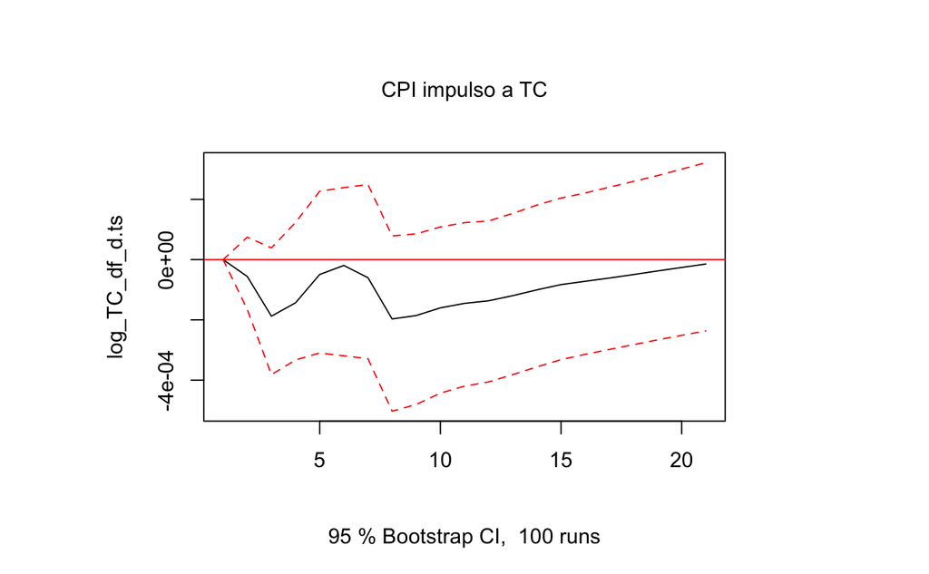

```r
M2<- irf(vec2var_ca_jo_eig, impulse = "log_CPI_df_d.ts", response = "log_TC_df_d.ts", n.ahead = 20, boot = TRUE)
plot(M2, ylab = "log_TC_df_d.ts", main = "CPI impulso a TC")
```

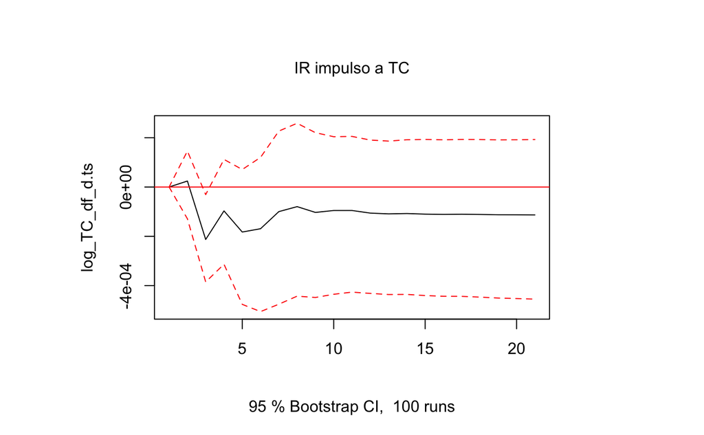

```r
M3<- irf(vec2var_ca_jo_eig, impulse = "log_IR_df_d.ts", response = "log_TC_df_d.ts", n.ahead = 20, boot = TRUE)
plot(M3, ylab = "log_TC_df_d.ts", main = "IR impulso a TC")
```

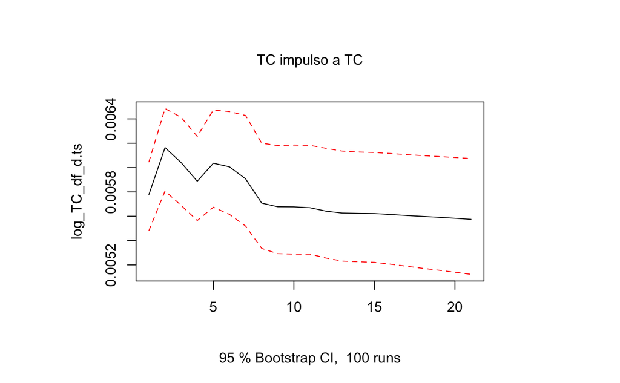

```r
M4<- irf(vec2var_ca_jo_eig, impulse = "log_TC_df_d.ts", response = "log_TC_df_d.ts", n.ahead = 20, boot = TRUE)
plot(M4, ylab = "log_TC_df_d.ts", main = "TC impulso a TC")
```

```r
NA
NA
```

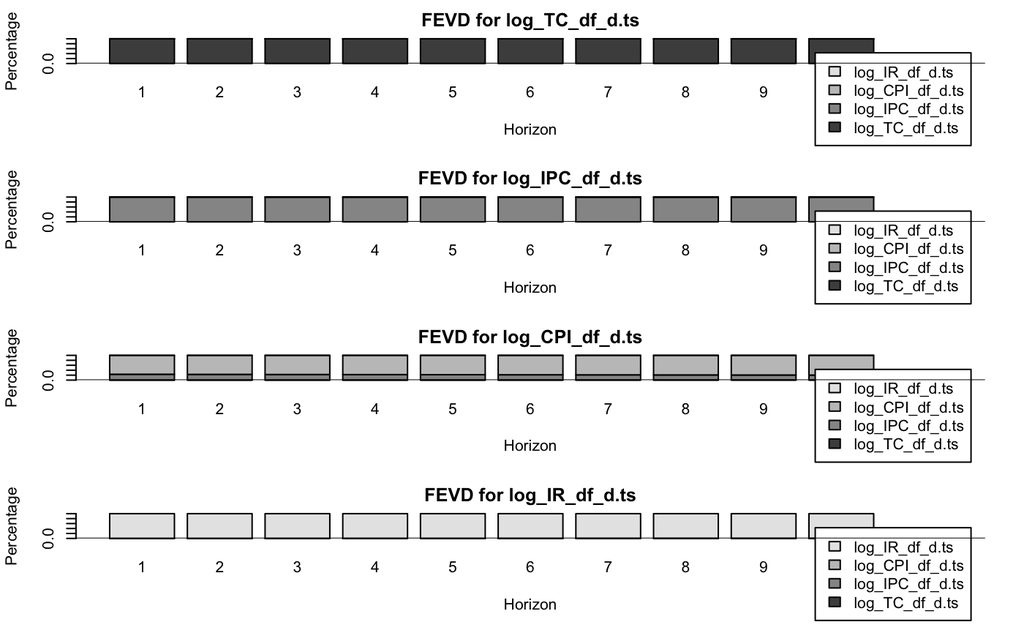

```r
plot(fevd(vec2var_ca_jo_eig))
```

```r
fevd(vec2var_ca_jo_eig)
```

```
$log_TC_df_d.ts
      log_TC_df_d.ts log_IPC_df_d.ts log_CPI_df_d.ts log_IR_df_d.ts
 [1,]      1.0000000    0.0000000000    0.000000e+00   0.000000e+00
 [2,]      0.9998135    0.0001343251    4.395585e-05   8.238572e-06
 [3,]      0.9990530    0.0001662009    3.556555e-04   4.251628e-04
 [4,]      0.9990593    0.0001398909    4.131378e-04   3.876433e-04
 [5,]      0.9990303    0.0001320289    3.426022e-04   4.950320e-04
 [6,]      0.9989302    0.0002379347    2.868570e-04   5.449757e-04
 [7,]      0.9987078    0.0005224868    2.611332e-04   5.085731e-04
 [8,]      0.9982840    0.0008758979    3.679865e-04   4.721242e-04
 [9,]      0.9979457    0.0011575902    4.393994e-04   4.573213e-04
[10,]      0.9977305    0.0013564412    4.722263e-04   4.408723e-04

$log_IPC_df_d.ts
      log_TC_df_d.ts log_IPC_df_d.ts log_CPI_df_d.ts log_IR_df_d.ts
```

[output cut: 36 more lines]

```
Invalid variable name(s) supplied, using first variable.
```

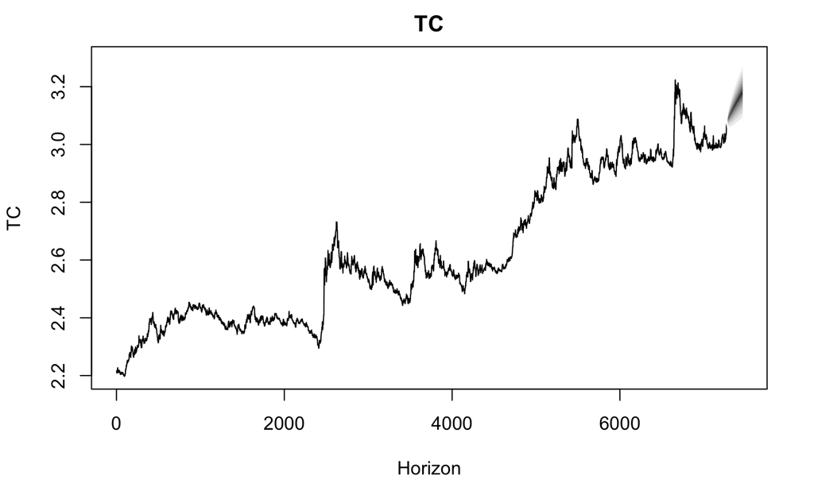

```r
forecast<-predict(vec2var_ca_jo_eig,n.ahead=182, ci=0.95)
fanchart(forecast,names="TC",main="TC",xlab="Horizon",ylab = "TC")
```

**Dado que también se realizó el pronóstico para meses que ya pasaron, podemos ver que tanto se aproximaron los valores reales a estos**

```r
#Archivo con serie completa
TC_df_serie_completa<- read_csv("csv_files/TC_df.csv") #serie completa
```

```r
#Filtrar para comparar pronóstico
TC_df_serie_completa<-subset(TC_df_serie_completa, date>as.Date("2021-11-30"))#
#agregar valores prónosticados, intervalo inferior, intervalo superior

#Fechas de predicción para construir dataframe final
fechas_pred<-seq(as.Date("2021-12-01","%Y-%m-%d"), as.Date("2022-05-31","%Y-%m-%d"),"day",drop=F)

#Valores prónosticados
int_inf<-exp(as.data.frame(forecast[["fcst"]][["log_TC_df_d.ts"]])$lower)
val_<-exp(as.data.frame(forecast[["fcst"]][["log_TC_df_d.ts"]])$fcst)
int_sup<-exp(as.data.frame(forecast[["fcst"]][["log_TC_df_d.ts"]])$upper)

val_pron<-as.data.frame(list(fechas_pred,int_inf,val_,int_sup))
names(val_pron)<-c("date","int_inf","pronostico","int_sup")
val_pron_vs_orig<-merge(val_pron, y = TC_df_serie_completa, by = "date", all.x = TRUE)
val_pron_vs_orig
```

| date | int_inf | pronostico | int_sup | value |
| --- | --- | --- | --- | --- |
| 2021-12-01 | 21.59894 | 21.84497 | 22.09380 | 21.7333 |
| 2021-12-02 | 21.48544 | 21.84426 | 22.20906 | 21.4453 |
| 2021-12-03 | 21.40224 | 21.84262 | 22.29206 | 21.2710 |
| 2021-12-04 | 21.35600 | 21.86189 | 22.37975 | 21.3033 |
| 2021-12-05 | 21.30981 | 21.87624 | 22.45774 | 21.3033 |
| 2021-12-06 | 21.26583 | 21.88626 | 22.52480 | 21.3033 |
| 2021-12-07 | 21.22209 | 21.89044 | 22.57983 | 21.4177 |
| 2021-12-08 | 21.19174 | 21.90215 | 22.63637 | 21.2047 |
| 2021-12-09 | 21.16600 | 21.91575 | 22.69206 | 21.0907 |
| 2021-12-10 | 21.14211 | 21.92920 | 22.74558 | 20.9330 |

[output cut: 172 more lines]

```r
#guardar valores
write.csv(val_pron_vs_orig, "csv_files/TC_valores_pronosticados.csv")
```

**Gráfica con límites**

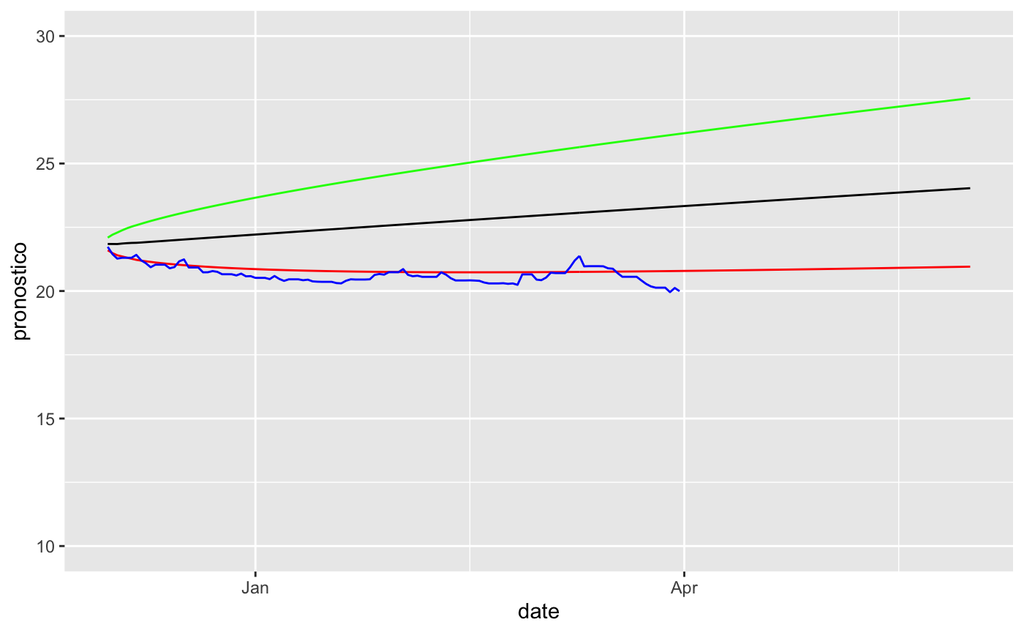

```r
ggplot(val_pron_vs_orig, aes(date)) +
    geom_line(aes(y = pronostico), color = "black") +
     geom_line(aes(y = int_inf), color = "red") +
    geom_line(aes(y = int_sup), color = "green") +
    geom_line(aes(y = value), color = "blue") +
  ylim(10, 30)
```

Nuestro límite inferior parece ajustarse mejor a los valores reales que hemos tenido de Tasa de cambio, sin duda aun hay cambios que se podrían intertar el modelo, por ejemplo, intentar modelar con otro tipo de perioricidad y obtener los valores de predicción diarios usando interpolación.